# Week 4 Assignment

Nguyen

23 March, 2022

# Introduction

- Link to my **Milk Price Watch** app: https://anhnguyenvnnz.shinyapps.io/week4shinyapp/
- Link to this presentation: https://a3guyen.github.io/2022-Assignments-for-DDP-course/Week4Assignment.html
- Purpose: This app shows price changes from global dairy trade (GDT) events. GDT events occur twice a month - on the first and the third Tuesday of each month.
- After each GDT event, there would be a change in GDT price index (% change). This data is recorded in a Google sheet.
- The app gets data from that Google sheet and show the latest results plus historical changes based on users’ selections in year and number of events.

# Packages

- The following are packages used to build this app

```r
library(shiny)
library(shinydashboard)
library(DT)
library(shinyWidgets)
library(dplyr)
library(googlesheets4)
library(plotly)
library(zoo)
library(leaflet)
```

# Usage - GDT Results tab

- The top left corner of this tab is an information box that shows the latest GDT results. The color is red if it is a reduction in price and green if it is an increase in price.
- There is 1 slider to select the year period (Year Slider) and a numeric input (Number of latest events) for users to choose to show historical data in the graph and table underneath.
- The bar chart and data table on this tab are the results of the data filtered by both **Year Slider** and **Number of latest events**.

# Usage - Fonterra Site Locations

- This tab is just my attempt to use Leaflet map in Rshiny. It is not related to milk price. FYI: Fonterra is the largest milk producer and exporter in New Zealand.
- Some embedded R code that gets run when slidifying the document (this has nothing to do with my app but is a requirement for the assigment presentation file):

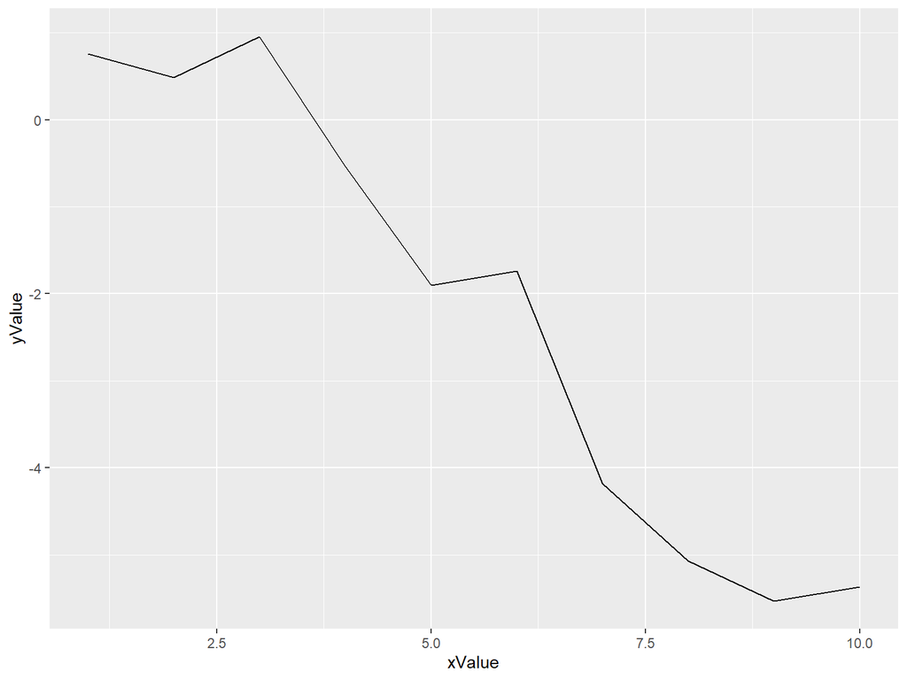

```r
library(ggplot2)
xValue <- 1:10
yValue <- cumsum(rnorm(10))
data <- data.frame(xValue,yValue)
ggplot(data, aes(x=xValue, y=yValue)) +
  geom_line()
```